# CodingChallenge4_Markdown

Jacobo

2026-02-25

## Answers

[Endophytic Fungi as a Promising Biocontrol Agent to Protect Wheat from Fusarium graminearum Head Blight](https://apsjournals.apsnet.org/doi/10.1094/PDIS-06-21-1253-RE)

[Link to my github repo](https://github.com/Jake-Ramirez/github-markdown-demo/tree/master)

### 1. 4 pts. Explain the following

**a. YAML header**

A YAML header is a block of metadata placed at the top of markdown documents. It defines settings and parameters such as title, author, date and default output format.

**b. Literate programming**

Is basically a way of documenting a pipeline treating code as logic chunks where each one goes along a paragraph of text explaining the functioning and purpose inside the whole script.

### 2. 6 pts. Take the code you wrote for coding challenge 3, question 5, and incorporate it into your R markdown file. Some of you have already been doing this, which is great! Your final R markdown file should have the following elements.

**a. At the top of the document, make a clickable link to the manuscript where these data are published. The link is here:**

[Check link up there ^](https://apsjournals.apsnet.org/doi/10.1094/PDIS-06-21-1253-RE)

```r
dataset <- read.csv("MycotoxinData.csv")
```

**c. Make a separate code chunk for the figures plotting the DON data, 15ADON, and Seedmass, and one for the three combined using ggarrange.**

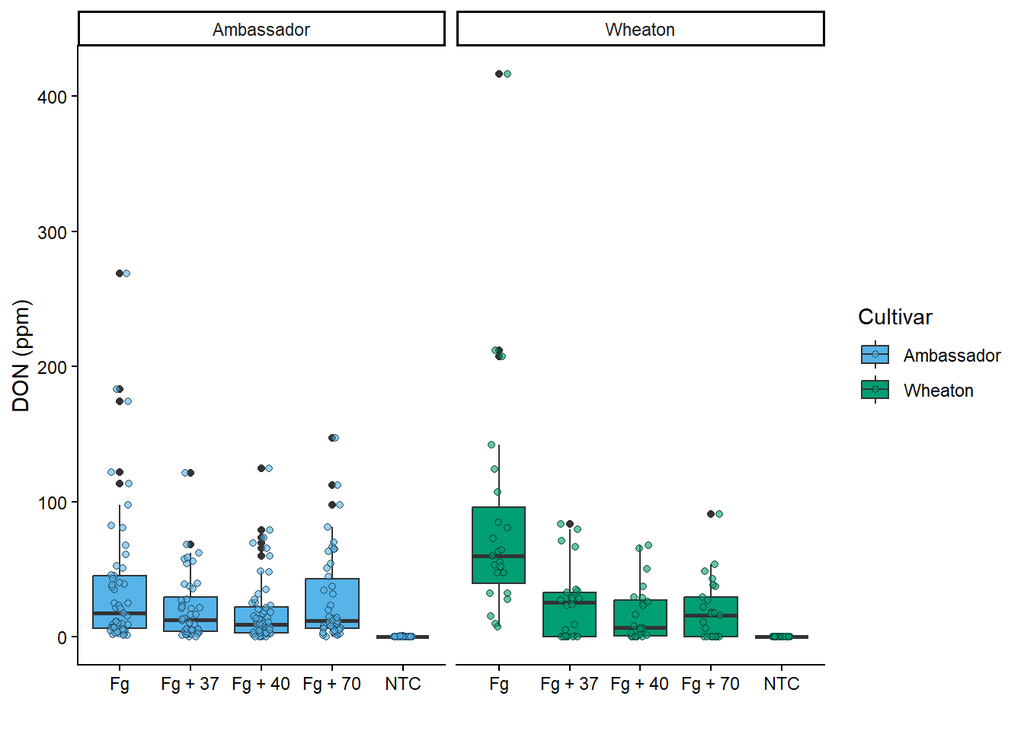

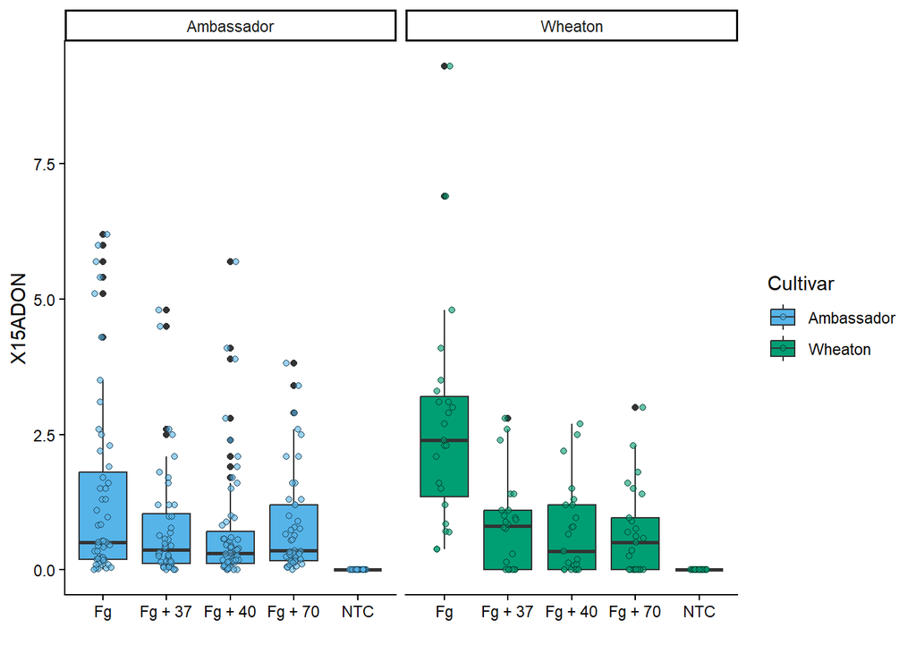

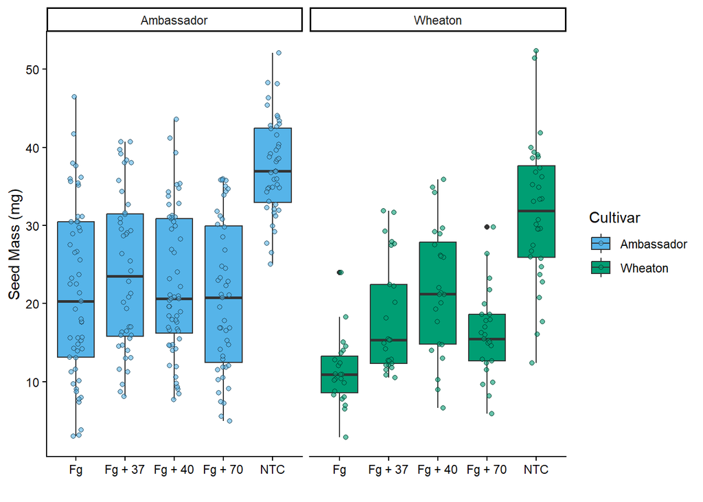

- In a separate chunk (echo is set to false for space)

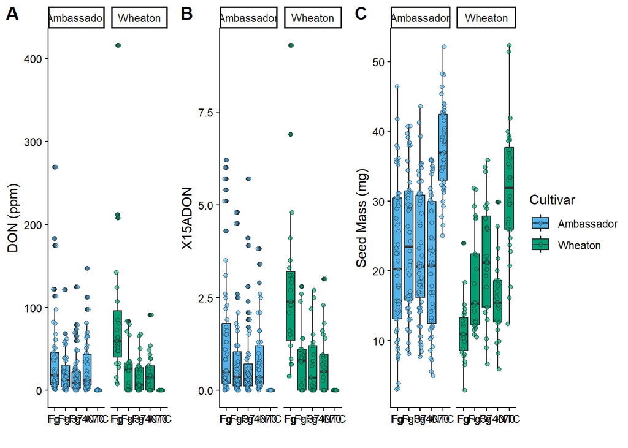